# Null Hypothesis & Gut Microbial Community and Multiple Sclerosis

Wang YueDuo, sdu202000700268

2022-03-25

# Part 1

## Question 1: State the Null Hypothesis for each of the following research questions.

### My answer:

### Do stickleback fish occur with equal probability through all areas of a pond?

All the stickleback fish occur with equal probability through all areas of a pond.

### Do patients change in mean body mass during a hospital stay?

Patients do not change in mean body mass during a hospital stay.

### Does the amount of rainfall per day in a rainforest have a normal distribution?

The amount of rainfall per day in a rainforest have a normal distribution.

### Which sex weighs more on average in bald eagles: males or females?

The average weights in males and females bald eagles are the same, there are no differences them.

### Do cats have greater strength in their dominant front paw (usually the right) than in their other front paw (usually the left)?

The left and right paw of cats have same strength, there are no differences between them.

# Part 2

## Question 1: Write down the Null and the alternative hypotheses.

### My answer:

Our research question is: Do the non-pathogenic gut microbes trigger onset of EAE? The null hypotheses is: The non-pathogenic gut microbes do not trigger onset of EAE, the relationship between them are independent. The alternative hypotheses is: The non-pathogenic gut microbes do trigger onset of EAE, the relationship between them are not independent.

## Question 2: Present the data on box plots and histograms:

### My answer:

```r
#First of all, let read the data file
eae.df <- read.csv("eae.csv",stringsAsFactors = T)
View(eae.df)

#Separate out the discrete data:
GF <- eae.df[eae.df$group == "GF", "autoreactive"]
SPF <- eae.df[eae.df$group == "SPF", "autoreactive"]
#Print out the discrete data
GF
```

```
## [1] 11.64  4.51  1.12  2.62  0.37  0.61  0.71  0.82
```

```r
SPF
```

```
## [1] 18.87 15.65 13.45 12.95  6.01  1.84  0.56  2.46
```

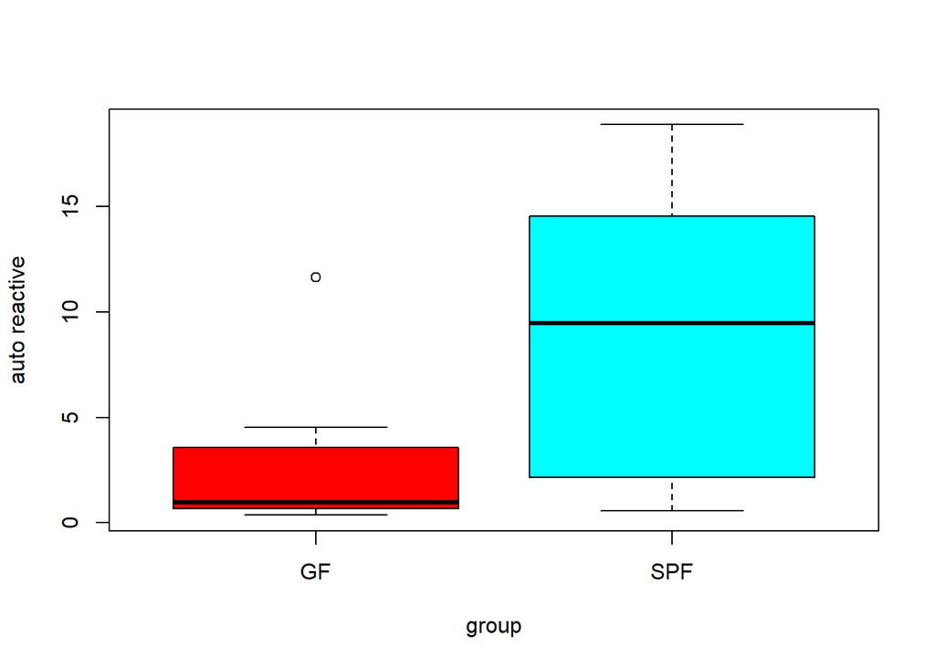

```r
#Then, make a box plot for discrete data:
boxplot(GF, SPF,
        col= rainbow(2) ,
        names = c("GF","SPF"),
        xlab = "group",
        ylab = "auto reactive",
        varwidth = T)
```

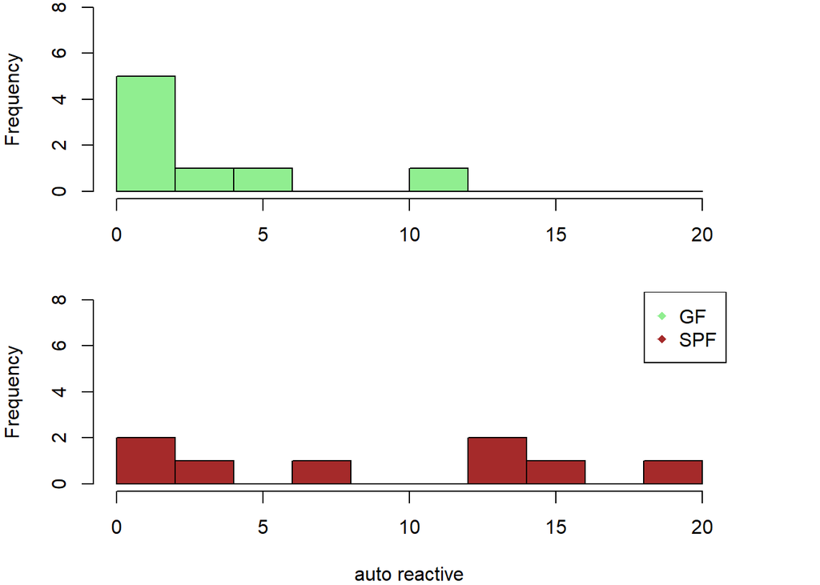

```r
#Make histograms for GF and SPF group
par(mfrow=c(2,1))
par(mar = c(4, 4, 0, 4))
hist(GF, col= "lightgreen",breaks = seq(0, 20, 2),ylim=c(0,8), freq=T,xlab="", main="")
hist(SPF, col= "brown", freq=T,breaks = seq(0, 20, 2), ylim=c(0,8),xlab="auto reactive", main="")

#Add a legend
legend("topright",
    legend=c("GF","SPF"),
    col=c("lightgreen","brown"),
    pch=18)
```

## Question3: Visually and formally assess normality of the data.

### My answer:

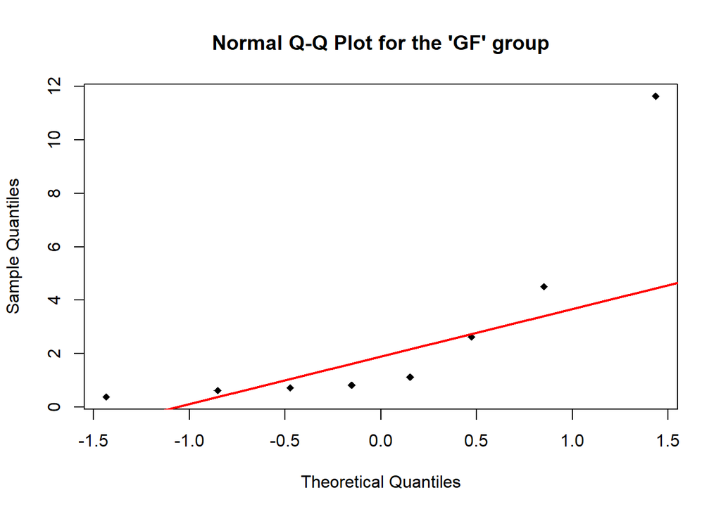

```r
#Make Q-Q plots including normal line for GF group:
qqnorm(GF,pch=18, main = "Normal Q-Q Plot for the 'GF' group")
qqline(GF,col="red",lwd=2)
```

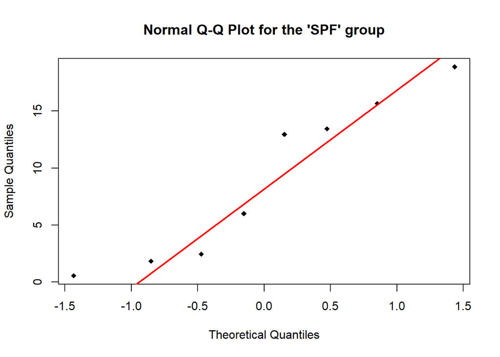

```r
#Make Q-Q plots including normal line for SPF group:
qqnorm(SPF,pch=18, main = "Normal Q-Q Plot for the 'SPF' group")
qqline(SPF,col="red",lwd=2)
```

Then, we use Shapiro-Wilk test, in order to statistically assess the data normality.

```r
#For "GF" group:
shapiro.test(GF)
```

```
##
##  Shapiro-Wilk normality test
##
## data:  GF
## W = 0.68628, p-value = 0.001574
```

```r
#For "SPF" group:
shapiro.test(SPF)
```

```
##
##  Shapiro-Wilk normality test
##
## data:  SPF
## W = 0.89832, p-value = 0.279
```

Thus, we get p-value of “GF” is 0.001574 < 0.05, and p-value of “SPF” is 0.279 > 0.05 This means in “GF” group situation, we reject the Null Hypothesis, and the data is not normally distributed, while in “SPF” group situation, we can not reject the Null Hypothesis, the data is normally distributed.

## Question 4: Perform following statistical tests: t-test, Welch t-test, permutation test with 10,000 permutations, include histogram of the permuted data as in lecture 08.

### My answer:

#### Perform normal t-test:

```r
t.test(autoreactive ~ group, data = eae.df, alternative = "two.sided", var.equal = T)
```

```
##
##  Two Sample t-test
##
## data:  autoreactive by group
## t = -2.1679, df = 14, p-value = 0.04789
## alternative hypothesis: true difference in means between group GF and group SPF is not equal to 0
## 95 percent confidence interval:
##  -12.28171224  -0.06578776
## sample estimates:
##  mean in group GF mean in group SPF
##           2.80000           8.97375
```

#### Perform welch t-test:

```r
t.test(autoreactive ~ group, data = eae.df, alternative = "two.sided")
```

```
##
##  Welch Two Sample t-test
##
## data:  autoreactive by group
## t = -2.1679, df = 10.778, p-value = 0.05346
## alternative hypothesis: true difference in means between group GF and group SPF is not equal to 0
## 95 percent confidence interval:
##  -12.4575705   0.1100705
## sample estimates:
##  mean in group GF mean in group SPF
##           2.80000           8.97375
```

#### Now permutation test with 10,000 permutations. (This problem draws lessons from workshop08-Question4)

```r
#Permutation test with 10,000 permutations:
#First, calculate the mean difference between GF and SPF group:
mean <- mean(SPF) - mean(GF)
mean
```

```
## [1] 6.17375
```

```r
#Plan our code:
perm <- double(0)

#Plan the permutations:
p <- sample(eae.df$autoreactive)
p.GF <- p[1:length(GF)]
p.SPF <- p[length(GF):length(p)]

#p - shuffled column eae.df$autoreactive
#p.GF - shuffled ‘GF’ category: first 8 randomly shuffled values from p are assigned to this category
#p.SPF - shuffled ‘SPF’ category: remaining values from p are assigned to this category

#(this explanation is referenced from workshop08-Question4)
```

```r
#Now print out p, p.GF, p.SPF:
p
```

```
##  [1]  0.56 13.45 12.95  0.71  0.82 15.65 18.87  0.61  2.62  6.01  1.12 11.64
## [13]  0.37  4.51  1.84  2.46
```

```r
p.GF
```

```
## [1]  0.56 13.45 12.95  0.71  0.82 15.65 18.87  0.61
```

```r
p.SPF
```

```
## [1]  0.61  2.62  6.01  1.12 11.64  0.37  4.51  1.84  2.46
```

```r
#Add mean difference:
p.mu <- mean(p.GF) - mean(p.SPF)
p.mu
```

```
## [1] 4.488056
```

```r
#Run for 10,000 times, and get the outputs:
N <- 10000
perm <- double(0)
for(i in 1:N){
  p <- sample(eae.df$autoreactive, length(eae.df$autoreactive), replace = F)
  p.GF <- p[1:length(GF)]
  p.SPF <- p[length(GF + 1):length(p)]
  p.mu <- mean(p.GF) - mean(p.SPF)
  perm <- c(perm, p.mu)
}
```

```r
#Calculate the absolute value of the observed mean:
mean.abs <- abs(mean)
mean
```

```
## [1] 6.17375
```

```r
#Subset the perm vector to get the more extreme means:
perm.sig <- perm[perm < -mean.abs | perm > mean.abs]
perm.sig.n <- length(perm.sig)
perm.sig.n
```

```
## [1] 284
```

```r
#Find the not extreme means:
perm.nsig <- perm[!(perm < -mean.abs | perm > mean.abs)]
perm.nsig.n <- length(perm.nsig)
perm.nsig.n
```

```
## [1] 9716
```

```r
#Check ssertion:
perm.nsig.n + perm.sig.n == N
```

```
## [1] TRUE
```

```r
#The ssertion is TRUE, thus we can calculate the p-value
p.pval <- perm.sig.n / length(perm)
p.pval
```

```
## [1] 0.0284
```

```r
#Then, we get p-value
```

#### Now perform histogram of the permuted data. (This problem draws lessons from workshop08-Question5)

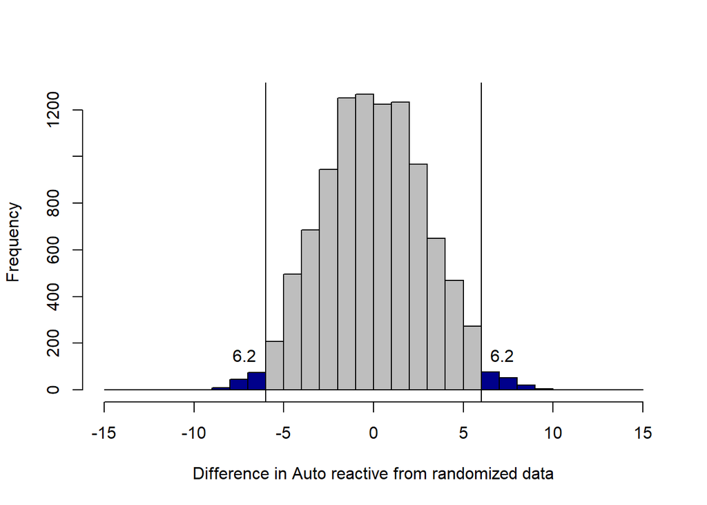

```r
hist(perm.nsig, breaks = -15:15, col = "gray", main = "", xlab = "Difference in Auto reactive from randomized data")
hist(perm.sig, breaks = -15:15, col = "darkblue", add = T)

#Two vertical lines at +/- mean
abline(v = -round(mean.abs, 0))
abline(v = round(mean.abs, 0))

#Two labels with the +/- mean
text(-round(mean.abs, 5) - 1, 150, sprintf('%.1f', mean.abs))
text(round(mean.abs, 5) + 1, 150, sprintf('%.1f', mean.abs))
```

## Question 5: Using full sentences critically describe results of your analysis.

### My answer:

#### Was the box plot well suited to present the data?

Exclude the outlier, from the box plot,we can observe that the auto reactive mean of GF(about 3) is much less than that of SPF(about 9). This indicates that there is a high possibility to reject null hypothesis.

#### Was the histogram well suited to present the data?

From the histogram, we got the relationship between the auto reactive of “GF” and “SPF” group and frequency. Most samples in “GF” group have auto reactive value less than 10, and there is no auto reactive value that more than 15, while in “SPF” group, there do exist samples that auto reactive value is more than 15.

#### Were the data normally distributed?

In Shapiro-Wilk test, we got p-value of “GF” is 0.001574 < 0.05, and p-value of “SPF” is 0.279 > 0.05. This means in “GF” group situation, we reject the Null Hypothesis, the data is not normally distributed, while in “SPF” group situation, we can not reject the Null Hypothesis, the data is normally distributed.

#### What are the differences in assumptions between t-test and Welch t-test?

In two-sample test, if the variences between two samples are equal or approximately equal, we call it “homogeneity of variance”. In this situation, welch t-test and normal t-test would have the same or approximate result, and meet assumptions of normal t-test.

Conversely, if the variences are not equal or approximately equal, normal t-test would present an inaccurate result. This situation is not meet assumptions of normal t-test. To correct it, we use welch t-test.

#### Do the data meet assumptions of the t-test? Explain why or why not (you can do some extra calculations here).

To solve this, we calculate the variances between “GF” and “SPF” group.

```r
var(GF)
```

```
## [1] 14.702
```

```r
var(SPF)
```

```
## [1] 50.17854
```

```r
var <- var(SPF)/var(GF)
#Then we get the variances, we can obverse how much do they differ.
var
```

```
## [1] 3.413042
```

Thus, we find that the variance of “SPF” group is 3.4 times bigger than variance of “GF” group, which means that they are not equal or approximately equal. Thus, we consider the data not meet assumptions of the normal t-test.

#### Do the data meet assumptions of the Welch t-test? Explain why or why not.

Because the variance of “SPF” group is 3.4 times bigger than variance of “GF” group, which means that they are not equal or approximately equal. Thus, we consider the data meet assumptions of thw welch t-test.

## Question 6: Write 5-10 sentences discussing the results, conclusions and answer to the research question. You should critically discuss the outcomes of three tests. Include your comments and thoughts on how this experiment could be improved and what were its weak points.

### My answer:

In this research, our research question is: Do the non-pathogenic gut microbes trigger onset of EAE? (The null hypotheses is: The non-pathogenic gut microbes do not trigger onset of EAE, the relationship between them are independent, while the alternative hypotheses is: The non-pathogenic gut microbes do trigger onset of EAE, the relationship between them are not independent.)

We separated out the discrete data into two groups: “GF”(germ-free^2) group and “SPF”(specific-pathogen-free^3) group, then we made box plots, histograms to present data in each of these two groups.

From the box plot (exclude the outliers), we can observe that the auto reactive mean of GF(about 3) is much less than that of SPF(about 9), which indicates that there is a high possibility to reject null hypothesis. From the histogram, we get the relationship between the auto reactive of “GF” and “SPF” group and frequency. Most samples in “GF” group have auto reactive value less than 10, and there is no auto reactive value that more than 15, while in “SPF” group, there do exist samples that auto reactive value is more than 15.

Then we made Q-Q plots including normal lines for each “GF” and “SPF” group, and performed Shapiro-Wilk test to statistically assess the data normality. In this test, We got p-value of “GF” is 0.001574 < 0.05, and p-value of “SPF” is 0.279 > 0.05, which means in “GF” group situation, we reject the Null Hypothesis, the data is not normally distributed, while in “SPF” group situation, we can not reject the Null Hypothesis, the data is normally distributed.

After that we presented t-test, welch t-test and permutation test with 10,000 permutations that include histogram of the permuted data. Because the data in “GF” situation is not normally distributed, we used permutation test to get the p-value.

#### Final conclusion:

The non-pathogenic gut microbes do trigger onset of EAE.

#### Open comments:

Independent variable must be controlled: such as the breed, age, diet of mice.

In addition, the mice must be fed and maintained in sterile environment, to prevent exogenous microbes cause pollution and interferes.

It would be better if more data were collected, in order to get a more accurate answer.

## End of Assignment 03: Null Hypothesis & Gut Microbial Community and Multiple Sclerosis